```python
%%javascript
IPython.OutputArea.prototype._should_scroll = function(lines) {
    return false;
}
```

# Post Goals:

1. Introduction to A/B Testing.
2. Demonstrate how to carry out an A/B test using Python.

# Post Overview.

1. Introduction to A/B Testing.
2. Example Case Details.
3. Conducting an A/B Test using Python.

# Introduction to A/B Testing.

**What is A/B Testing?**

- A/B testing is also called split testing, bucket testing, and split-run testing.
- A/B testing refers to a randomized experimental technique used to compare the affects of a user's behavior to two versions of a single variable (A and B).
- A/B testing is used to determine whether a version brings improvements to a chosen business metric.
- A/B testing is commonly conducted on online, mobile, application software and by large social media sites.
- A/B testing are useful at understanding how online features affect user engagement and satisfaction.
- A/B testing in web development has been routinely conducted since the 2000s, and since then A/B testing is used in more complex experiments, and is an essential knowhow for any data scientist.
- The goal of A/B testing is to challenge an existing version of a web feature (A) with a new one (B), by randomly splitting traffic and comparing metrics on each of the splits.

**A/B Test Case Example**

[figure not shown]

- A company is currently using version A of a landing page (control).
- The company is considering a new landing page arrangement (treatment) and want test if the new layout increases key business metrics.
- The metrics the company will test include:
  - Average time spent on landing page.
  - Conversion rate (proportion of sessions that result in a transaction).
- Using an A/B test will help the company make an informed decision based on empirical data and statistical testing.

**Common Business Metrics Tested**

- **Engagement metrics:** are a set of variables that include time spent on a site, unique visitors, page views, page/scroll depth, number of people who visit a page, and click-through rate, to name a few. Some of these are calculated using averages.
- **Conversion Rates:** measures how many visitors performed a desired action, and includes making a purchase, signing up for an email list, filling out a form, completing a survey, subscribing to a service, or adding a comment or review.  
  \[Conversion\ Rate = {\frac{Action\ completed}{Site\ Visitors} }\]
- **Average Time Spent (Session Duration):** is measures that describes the average time visitors spent on the website as a whole (Average Session/Time spent), or the average time visitors spent on a specific page (Average time on page).  
  \[Average\ Time = {\frac{\Sigma(Time\ spent\ by\ visitor)}{Total\ Number\ of\ Visitors)} }\]
- **Bounce Rates:** is a type of engagement metric that measures how many visitors enter the landing page but leave without continuing to view other pages in the same site.  
  \[Bounce\ Rate = R_{b}\ = {\frac{T_{v}}{T_{e}} } \] \[T_{v} = Total\ one\ page\ visits\] \[T_{e} = Total\ entrance\ visits\]
- **Exit Rates:** is a type of engagement metric that measures the number of times visitors have left a site from a single page. The page's exit rate indicates how often visitors exit from it after visiting any number of pages.  
  \[Exit\ Rate = R_{e}\ = {\frac{T_{exits}}{T_{views}} } \] \[T_{exits} = Total\ exits\ from\ page\] \[T_{views} = Total\ visits\ to\ page\]

**Common test statistics**

- A/B Testing includes statistical hypothesis testing.
- The test metric typically dictactes which test statistics to use.

[output not shown]

# Case Details

## This post will demonstrate how to conduct an A/B test:

- using python
- will evaluate the affects of the A/B test on Average Time spent on the landing page.
- the Z-test test statistics will be used to determine significance.

## The Data:

- The company in this example provided the following data for the analysis.

[output not shown]

| Version | Number of sessions | Average Time on Landing (seconds) | Standard Devision of Time on Landing (seconds) | Conversion Rate (%) |
| --- | --- | --- | --- | --- |
| A | 6000 | 59 | 39 | 1.51 |
| B | 4000 | 61 | 44 | 2.02 |

# Conducting an A/B Test using Python - Process Overview

1. State the Null Hypotheis \(H_{o} \).
2. State the Alternative Hypotheis \(H_{a} \).
3. Select a Significance Level \(\alpha \).
4. Model \(H_{o} \) with Central Limits Theorem.
5. Determine the likelyhood of \(H_{o} \) by calculating the p-value using the Z-test statistics.
6. Interpret results.

# State the Null Hypotheis \(H_{o} \)

**Null Hypothesis**

- Is a statistical hypothesis that assumes that the observation from the data is due to a chance factor and proposes no significant difference exists between a set of given observations.
- The Null Hypothesis \(H_{o} \) states that the two populations that are compared have the same mean.
- In this example, the Null Hypothesis \(H_{o} \) states that there is **no difference** in the average time visitors spent on either version (A or B) of the landing page and is expresses as follows:
- Null Hypotheis \(H_{o}: \mu_{A} = \mu_{B} \):  
  Where \(\mu_{A} \) is the mean time visitors spent in landing page version A  
  and \(\mu_{B} \) is the mean time visitors spent in landing page version B

# State the Alternative Hypotheis \(H_{a} \)

**Alternative Hypothesis**

- Is a statistical hypothesis that assumes that the observation from the data is due to a chance factor and proposes that there is a significant difference between a set of given observations.
- The Alternative Hypothesis \(H_{a} \) states that the two populations that are compared have different means. In this example, company wants to test if Version B has a higher mean.
- In this example, the Alternative Hypothesis \(H_{a} \) states that there **is a difference** in the average time visitors spent between version (A or B) of the landing page, and specifically, the average time spent on landing page version B will be greater than landing page version A, and is expressed as follows:
- The Alternative Hypotheis \(H_{A} \):  
  \[H_{A}: \mu_{A} < \mu_{B} \]  
  Where \(\mu_{A} \) is the mean time visitors spent in landing page version A  
  and \(\mu_{B} \) is the mean time visitors spent in landing page version B

# Select a Significance Level \(\alpha \)

**Levels of Significance \(\alpha \)**

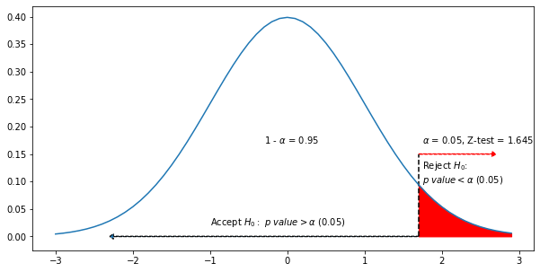

```python
import matplotlib.pyplot as plt
import numpy as np
from scipy.stats import norm

z = np.arange(-3, 3, 0.1)
Z = 1.645 # upper-tailed test where alpha = 0.05

plt.figure(figsize=(10,5)) # figure size
plt.plot(z, norm.pdf(z)) # plots the z curve using normal probability distribution
# fills in area where Z-test is 0.05 and above
plt.fill_between(z[z>Z], norm.pdf(z[z>Z]), color="red")

# Plots area where Null Hypothesis is accepted
plt.text(-1, 0.02, r'Accept $H_{0}:\ p\ value > \alpha\ (0.05)$', fontsize=10)
plt.text(-0.3, 0.17, r'1 - $\alpha$ = 0.95', fontsize=10)
plt.arrow(x=z[z>Z][0], y=0, dx=-4, dy=0, shape='full', head_length= 0.05, head_width=0.01, length_includes_head=True, linestyle='--')

# Plots area where Null Hypothesis should. be rejected
plt.vlines(z[z>Z][0], 0, 0.15, colors="black", linestyle="dashed")
plt.text(1.75, 0.098, r'Reject $H_{0}$:''\n'r'$p\ value < \alpha\ (0.05)$', fontsize=10)
plt.text(1.75, 0.17, r'$\alpha$ = 0.05, Z-test = 1.645', fontsize=10)
plt.arrow(x=z[z>Z][0], y=0.15, dx=1, dy=0, shape='full', head_length= 0.05, head_width=0.01, length_includes_head=True, color="red", linestyle='--')

plt.show()
```

# Model \(H_{o} \) with Central Limits Theorem

**Modeling the \(H_{o} \) using the Z-test statistic**

- To reiterate the hypothesis
  - \(H_{o}: \mu_{a} = \mu_{B} \) = the mean time visitors spend on landing page version A and B are the same.
  - \(H_{a}: \mu_{a} < \mu_{B} \) = the mean time visitors spend on landing page version B is greater than version A.
- The Z-test uses the Central Limit Theorem (CLT) to test the hypothesis, and CLT will be briefly discussed to explain our \(H_{o} \) modeling.

**Central Limits Theorem**

- The central limits theorem is a statistical theory that states that given a sufficiently large sample size from a population with a finite level of variance, the mean of all the samples from the same population will be approximately equal to the mean of the population.
- Moreover, when you sample a population many times, the distribution of the means of all the samples are normally distributed, regardlesss of the population distribution.
- Normally distributed just means that if you plot the probability distribution, it will be symmetric about the mean, and give you that bell shaped curve.
- The highest frequency value will be the population mean.
- **Why does this matter?** it helps us accurately predict characteristics of a population, and we can compare two populations, such as the population of visitors for landing page version A and landing page version B.
- The following section will bridge CLT and our hypothesis testing using the Z-test.

**Central Limits Theorem (CTL) and Hypothesis Testing**

- CTL states that for a given a random variable **X** (example time spent viewing landing page) with a given mean \(\mu \) and a finite variance \(\sigma^{2} \), the sampling of \(X_{1},...X_{n} ~ X \), **n** times will result in the following approximatation of the average:  
  \[\mu{(n,X)} = \frac{1}{n}\Sigma_{i=1}^{n}X_{i} \sim \mathcal{N}(\mu,\,\frac{\sigma^{2}}{n}) \]
- With this in mind, we can model the time spent for each client session **i** as the following:
  - for **\(a_{i} \)** of random variable **\(A_{i} \sim\ A \)**, if the client session belongs to the version wher we split the client to landing page version A
  - for **\(b_{i} \)** of random variable **\(B_{i} \sim\ B \)**, else
- We then use the approximation provided by the central limits theorem to derive:
  - \[\mu{(n_{A},A)} \sim \mathcal{N}(\mu_{A},\,\frac{\sigma^{2}_{A}}{n_{A}}) \]
  - \[\mu{(n_{B},B)} \sim \mathcal{N}(\mu_{B},\,\frac{\sigma^{2}_{B}}{n_{B}}) \]
- Then we can approximate the difference between version A and version B: \[\mu{(n_{B},B)} - \mu{(n_{A},A)} \sim \mathcal{N}(\mu_{B} - \mu_{A},\,\frac{\sigma^{2}_{B}}{n_{B}} + \frac{\sigma^{2}_{A}}{n_{A}})) \]
- Recall that the Null Hypothesis states \(H_{o}: \mu_{a} = \mu_{b} \). Which means we have equality of the true means and therefore the model, \(H_{o}: \mu_{a} = \mu_{b} = 0 \) and the above formula can be simplified:
  - \[\mu{(n_{B},B)} - \mu{(n_{A},A)} \sim \mathcal{N}(0,\,\frac{\sigma^{2}_{B}}{n_{B}} + \frac{\sigma^{2}_{A}}{n_{A}})) \]
  - \[\Leftrightarrow \frac{\mu{(n_{B},B)} - \mu{(n_{A},A)}}{\sqrt{\frac{\sigma_{B}^{2}}{n_{B}} + \frac{\sigma_{A}^{2}}{n_{A}}}} \sim \mathcal{N}(0,1) \]

# Determine the likelyhood of \(H_{o} \) by calculating the p-value using the Z-test statistics

**Mathematical Intuition**

- Since we do not know the true mean and variance for version A and version B, we must introduce empirical estimators:

  **Version A:**
  - \(\hat{\mu}_{A} = \frac{1}{n_{A}}\Sigma_{i}a_{i} \)
  - \(\hat{\sigma}_{A} = \frac{1}{n_{A}}\Sigma_{i}(\hat{\mu}_{A} - a_{i})^{2} \)

  **Version B:**
  - \(\hat{\mu}_{B} = \frac{1}{n_{B}}\Sigma_{i}b_{i} \)
  - \(\hat{\sigma}_{B} = \frac{1}{n_{B}}\Sigma_{i}(\hat{\mu}_{B} - b_{i})^{2} \)
- Our samples will then generate the following test statistic **Z**, which needs to be tested against the reduced central normal distribution: \[Z = \frac{\hat{\mu}_{B} - \hat{\mu}_{A}} {\sqrt{\frac{\hat{\sigma}_{B}^{2}}{n_{B}} + \frac{\hat{\sigma}_{A}^{2}}{n_{A}} }} \]
- **Z** represents the number of standard deviations the observed difference of the means is away from `0`.
- We are using `0` because of our Null Hypothesis \(H_{0}: \mu_{A} - \mu_{B} = 0\).
- The higher the Z number, the less likely that \(H_{0}: \mu_{A} - \mu_{B} = 0\) , and that means the less likely the Null Hypothesis is true, and that the Alternative Hypothesis may be true.
- From this formula you can also see that more samples are needed to prove a smaller difference.
- Hopefully in this section provided a link between CTL and the hypothesis testing in our A/B test.

**Calculate Z test statistics in Python**  
There are several methods to calculate the z test statistics, in this example we will manually calculate the p-value.

1. Import dependencies ([numpy](https://numpy.org/) and [scipy](https://docs.scipy.org/doc/scipy/reference/stats.html).stats).  
   **numpy** is used for scientific computing.  
   **scipy** is a library that contains a large number of probability distributions and statistical functions. We will use scipy [norm](https://docs.scipy.org/doc/scipy/reference/generated/scipy.stats.norm.html) to obtain a p-value from our corresponding Z test statistic.
2. Assign A/B testing values to variables.
3. Calcualte the Z test statistics using the formula: \[Z = \frac{\hat{\mu}_{B} - \hat{\mu}_{A}} {\sqrt{\frac{\hat{\sigma}_{B}^{2}}{n_{B}} + \frac{\hat{\sigma}_{A}^{2}}{n_{A}} }} \]
4. Then use the `norm.sf(Z)` method with our Z test statistics value to return the survival function. This function is defined as `1 - cdf` and will return the p-value for that Z test statistic.
5. Evaluate p-value

```python
import numpy as np
from scipy.stats import norm

mu_B = 61
mu_A = 59

std_B = 44
std_A = 39

n_B = 4000
n_A = 6000

Z = (mu_B - mu_A)/np.sqrt(std_B**2/n_B + std_A**2/n_A)
pvalue = norm.sf(Z)

print("Z-score: {0}\np-value: {1}".format(Z,pvalue))
```

```
Z-score: 2.328890038958328
p-value: 0.009932445885041307
```

# Interpret results

**Which hypothesis is support by the data?**

- By comparing the p-value to the level of signifiance \(\alpha \), we can determine if there is evidence to reject or support the null hypothesis.
- If the \(p-value > \alpha \): we accept the null hypothesis, and the mean time visitors spent on landing page A or B are the same. This would suggest that the difference in the landing page layout does not affect the time visitors spend viewing the page.
- If the \(p-value < \alpha \): we reject the null hypothesis, and the mean time visitors spent on landing page A is less than landing page B. This would suggest that the landing page layout for B does affect the amount of time visitors spend on this page, as compared to landing page A.
- Since \(p-value (0.01) < \alpha (0.05) \) we can conclude that the mean time visitors spend on the two versions of the landing page is not the same, and that the landing page version B has visitors that remain on that page longer than those that visit landing page version A.
- The plot below summarizes our findings.

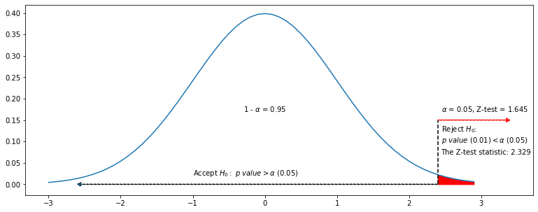

```python
plt.figure(figsize=(13,5)) # figure size
plt.plot(z, norm.pdf(z)) # plots the z curve using normal probability distribution
# fills in area where Z-test is 0.05 and above
plt.fill_between(z[z>Z], norm.pdf(z[z>Z]), color="red")

# Plots area where Null Hypothesis is accepted
plt.text(-1, 0.02, r'Accept $H_{0}:\ p\ value > \alpha\ (0.05)$', fontsize=10)
plt.text(-0.3, 0.17, r'1 - $\alpha$ = 0.95', fontsize=10)
plt.arrow(x=z[z>Z][0], y=0, dx=-5, dy=0, shape='full', head_length= 0.05, head_width=0.01, length_includes_head=True, linestyle='--')

# Plots area where Null Hypothesis should be rejected
plt.vlines(z[z>Z][0], 0, 0.15, colors="black", linestyle="dashed")
plt.text(Z*1.05, 0.07, f'The Z-test statistic: {np.round(Z,3)}')
plt.text(Z*1.05, 0.098, r'Reject $H_{0}$:''\n'r'$p\ value\ (0.01) < \alpha\ (0.05)$', fontsize=10)
plt.text(Z*1.05, 0.17, r'$\alpha$ = 0.05, Z-test = 1.645', fontsize=10)
plt.arrow(x=z[z>Z][0], y=0.15, dx=1, dy=0, shape='full', head_length= 0.05, head_width=0.01, length_includes_head=True, color="red", linestyle='--')

plt.show()
```